# Analysis of NBA Playoff Data

Sai Pranav Theerthala

## Introduction

The National Basketball Association is the premiere basketball league in the United States. The best players across the world join one of thirty teams and compete year round for the coveted NBA Championship.

The structure of the season is split apart into the regular season and playoffs. Each team's performance in the regular season determines if they make it to the playoffs as 1 of 16 qualifying teams. The teams perfomrance in the playoffs then determines who the eventual NBA champion will be.

For decades, NBA teams have tried finding the perfect balance between spending large amounts of money on the best stars and spending smart to creating a well rounded strong team. A team that spends money on stars will have more talent in their first 5 best players, while other teams will have more solid players in later positions. Both types of teams have found success in the past, but many believe there is a growing trend in deciding the champion.

Today, I walk you through a simple tutorial of a rudimentary algorithm for modeling NBA players and their impact to predict championship winners.

```python
import requests
import pandas as pd
import matplotlib.pyplot as plt
import numpy as np
from bs4 import BeautifulSoup
from selenium import webdriver
import unicodedata
import tensorflow as tf
from tensorflow.keras.models import Sequential
from tensorflow.keras.layers import Dense
from sklearn.model_selection import train_test_split
from sklearn.preprocessing import StandardScaler
from sklearn.metrics import classification_report, confusion_matrix, accuracy_score
```

```python
import warnings
warnings.simplefilter(action='ignore', category=FutureWarning)
warnings.simplefilter(action='ignore', category=pd.errors.SettingWithCopyWarning)
warnings.simplefilter(action='ignore', category=UserWarning)
```

## Data Collection

### Web Scraping Basketball Reference

In order to collect accurate data, I collected all playoff statistics from a well known NBA stats website, basketball reference, from the years 2019 to 2023 inclusive. I stored each DataFrame in a disctionary, with the year being a key that corresponding to the appropriate DataFrame.

```python
dataframes = {}

years = ["2019", "2020", "2021", "2022", "2023"]

for year in years:
    url = f"https://www.basketball-reference.com/playoffs/NBA_{year}_per_game.html"
    driver = webdriver.Chrome()
    driver.get(url)
    driver.implicitly_wait(10)
    html = driver.page_source
    soup = BeautifulSoup(html, 'html.parser')
    table = soup.find('table', {"class": "sortable stats_table now_sortable"})
    df_list = pd.read_html(str(table))
    dataframes[year] = df_list[0]
```

```python
print(dataframes['2020'])
```

```
      Rk               Player Pos Age   Tm   G  GS    MP   FG   FGA  ...  \
0      1         Jaylen Adams  PG  23  POR   3   0   7.0  1.0   3.0  ...
1      2         Steven Adams   C  26  OKC   7   7  30.0  4.4   7.4  ...
2      3          Bam Adebayo  PF  22  MIA  19  19  36.2  6.5  11.6  ...
3      4        Jarrett Allen   C  21  BRK   4   4  33.0  3.5   6.0  ...
4      5      Justin Anderson  SG  26  BRK   3   0   9.3  1.7   4.0  ...
..   ...                  ...  ..  ..  ...  ..  ..   ...  ...   ...  ...
222  213      Marvin Williams  PF  33  MIL  10   0  17.9  2.1   4.7  ...
223  214      Robert Williams   C  22  BOS  13   0  11.5  1.8   2.4  ...
224  215  Nigel Williams-Goss  PG  25  UTA   1   0   2.0  0.0   0.0  ...
225  216         Delon Wright  PG  27  DAL   4   0  13.3  1.5   2.5  ...
226  217          Ivica Zubac   C  22  LAC  13  13  24.6  3.4   6.0  ...

       FT%  ORB   DRB   TRB  AST  STL  BLK  TOV   PF   PTS
0      NaN  0.3   0.7   1.0  0.7  0.3  0.0  0.0  0.3   2.0
1     .450  4.9   6.7  11.6  1.3  0.6  0.3  2.3  1.4  10.1
2     .783  2.5   7.8  10.3  4.4  1.0  0.8  2.5  3.1  17.8
3     .813  4.3  10.5  14.8  2.3  0.5  1.8  2.8  1.8  10.3
4    1.000  0.0   2.7   2.7  1.0  0.0  0.3  0.7  0.7   6.3
..     ...  ...   ...   ...  ...  ...  ...  ...  ...   ...
222  1.000  1.3   3.5   4.8  0.9  0.5  0.3  0.3  1.4   5.5
223   .333  1.7   2.2   3.9  0.8  0.2  0.5  0.5  1.4   3.7
224    NaN  0.0   0.0   0.0  1.0  0.0  0.0  0.0  0.0   0.0
225   .600  0.3   0.5   0.8  1.8  1.3  0.0  1.3  0.5   4.0
226   .811  2.4   4.8   7.2  0.6  0.2  0.8  0.9  2.6   9.1

[227 rows x 30 columns]
```

```python
for year in years:
    columns_to_keep = ['Player', 'Tm', 'G', 'MP', 'PTS', 'TRB', 'AST', 'TOV', 'STL', 'BLK']
    dataframes[year] = dataframes[year][columns_to_keep]
```

```python
print(dataframes["2020"].head())
```

```
            Player   Tm   G    MP   PTS   TRB  AST  TOV  STL  BLK
0     Jaylen Adams  POR   3   7.0   2.0   1.0  0.7  0.0  0.3  0.0
1     Steven Adams  OKC   7  30.0  10.1  11.6  1.3  2.3  0.6  0.3
2      Bam Adebayo  MIA  19  36.2  17.8  10.3  4.4  2.5  1.0  0.8
3    Jarrett Allen  BRK   4  33.0  10.3  14.8  2.3  2.8  0.5  1.8
4  Justin Anderson  BRK   3   9.3   6.3   2.7  1.0  0.7  0.0  0.3
```

### Web Scraping Basketball RealGM

I also scraped this website in order to collect data about the allstars each year, as I would be making use of this data later on. Similar to all player stats, I stored each list in a disctionary, with the year being a key that corresponding to the appropriate list of all stars.

```python
allstars = {}

for year in years:
    url = f"https://basketball.realgm.com/nba/allstar/game/rosters/{year}"
    driver = webdriver.Chrome()
    driver.get(url)
    driver.implicitly_wait(10)
    html = driver.page_source
    soup = BeautifulSoup(html, 'html.parser')
    tables = soup.find_all('table', {"class": "basketball compact"})
    players = []

    for table in tables:
        df_list = pd.read_html(str(table))
        players.extend(df_list[0]['Player'])

    allstars[year] = players
```

## Data Processing

In this section, we use Pandas and NumPy to shape the data into more readable information for our purposes

Pandas: https://pandas.pydata.org/docs/index.html

NumPy: https://numpy.org/doc/stable/index.html

# Cleaning Up Playoff Stats

We first need to replace all three letter abbreviations of teams to correspond to the full name of the team in order to be more clear in out analysis and data presentation.

```python
teams = {
    'ATL': 'Atlanta Hawks',
    'BRK': 'Brooklyn Nets',
    'BOS': 'Boston Celtics',
    'CHA': 'Charlotte Hornets',
    'CHI': 'Chicago Bulls',
    'CLE': 'Cleveland Cavaliers',
    'DAL': 'Dallas Mavericks',
    'DEN': 'Denver Nuggets',
    'DET': 'Detroit Pistons',
    'GSW': 'Golden State Warriors',
    'HOU': 'Houston Rockets',
    'IND': 'Indiana Pacers',
    'LAC': 'Los Angeles Clippers',
    'LAL': 'Los Angeles Lakers',
    'MEM': 'Memphis Grizzlies',
    'MIA': 'Miami Heat',
    'MIL': 'Milwaukee Bucks',
    'MIN': 'Minnesota Timberwolves',
    'NOP': 'New Orleans Pelicans',
    'NYK': 'New York Knicks',
    'OKC': 'Oklahoma City Thunder',
    'ORL': 'Orlando Magic',
    'PHI': 'Philadelphia 76ers',
    'PHO': 'Phoenix Suns',
    'POR': 'Portland Trail Blazers',
    'SAC': 'Sacramento Kings',
    'SAS': 'San Antonio Spurs',
    'TOR': 'Toronto Raptors',
    'UTA': 'Utah Jazz',
    'WAS': 'Washington Wizards'
}
for year in years:
    dataframes[year]['Tm'] = dataframes[year]['Tm'].map(teams)
print(dataframes['2020'])
```

```
                  Player                      Tm   G    MP   PTS   TRB  AST  \
0           Jaylen Adams  Portland Trail Blazers   3   7.0   2.0   1.0  0.7
1           Steven Adams   Oklahoma City Thunder   7  30.0  10.1  11.6  1.3
2            Bam Adebayo              Miami Heat  19  36.2  17.8  10.3  4.4
3          Jarrett Allen           Brooklyn Nets   4  33.0  10.3  14.8  2.3
4        Justin Anderson           Brooklyn Nets   3   9.3   6.3   2.7  1.0
..                   ...                     ...  ..   ...   ...   ...  ...
222      Marvin Williams         Milwaukee Bucks  10  17.9   5.5   4.8  0.9
223      Robert Williams          Boston Celtics  13  11.5   3.7   3.9  0.8
224  Nigel Williams-Goss               Utah Jazz   1   2.0   0.0   0.0  1.0
225         Delon Wright        Dallas Mavericks   4  13.3   4.0   0.8  1.8
226          Ivica Zubac    Los Angeles Clippers  13  24.6   9.1   7.2  0.6

     TOV  STL  BLK
0    0.0  0.3  0.0
1    2.3  0.6  0.3
2    2.5  1.0  0.8
3    2.8  0.5  1.8
4    0.7  0.0  0.3
..   ...  ...  ...
222  0.3  0.5  0.3
223  0.5  0.2  0.5
224  0.0  0.0  0.0
225  1.3  1.3  0.0
226  0.9  0.2  0.8

[227 rows x 10 columns]
```

```python
winners = {
    "2019": "Toronto Raptors",
    "2020": "Los Angeles Lakers",
    "2021": "Milwaukee Bucks",
    "2022": "Golden State Warriors",
    "2023": "Denver Nuggets"
}
```

### Regularizing Text

Another data processing step was to make sure all the characters were pure english characters. There are multiple players in the NBA, such as Nikola Jokić, who have special characters in their names. To keep the data consistent, I normalized all characters to be one from the ASCII table.

```python
def normalize_name(name):
    return unicodedata.normalize('NFKD', name).encode('ASCII', 'ignore').decode('ASCII')

for year in years:
    dataframes[year]['Player'] = dataframes[year]['Player'].apply(normalize_name)
```

## Exploratory Data Analysis

```python
total_stats_df = pd.DataFrame(columns=['Year', 'Team', 'Category', 'G', 'MP', 'PTS', 'TRB', 'AST', 'TOV', 'STL', 'BLK'])
winning_team_all_stars_by_year = []

for year in years:
    winning_team = winners[year]
    winning_team_stats = dataframes[year][dataframes[year]['Tm'] == winning_team]

    winning_team_stats[['G', 'MP', 'PTS', 'TRB', 'AST', 'TOV', 'STL', 'BLK']] = winning_team_stats[['G', 'MP', 'PTS', 'TRB', 'AST', 'TOV', 'STL', 'BLK']].apply(pd.to_numeric, errors='coerce')

    allstar_stats = winning_team_stats[winning_team_stats['Player'].isin(allstars[year])]
    other_stats = winning_team_stats[~winning_team_stats['Player'].isin(allstars[year])]

    winning_team_all_stars_by_year.append(allstar_stats['Player'].tolist())

    allstar_total_stats = allstar_stats[['G', 'MP', 'PTS', 'TRB', 'AST', 'TOV', 'STL', 'BLK']].sum()
    other_total_stats = other_stats[['G', 'MP', 'PTS', 'TRB', 'AST', 'TOV', 'STL', 'BLK']].sum()

    allstar_total_stats['Year'] = year
    allstar_total_stats['Team'] = winning_team
    allstar_total_stats['Category'] = 'All-Stars'

    other_total_stats['Year'] = year
    other_total_stats['Team'] = winning_team
    other_total_stats['Category'] = 'Others'

    allstar_total_stats = allstar_total_stats.to_frame().T
    other_total_stats = other_total_stats.to_frame().T

    total_stats_df = pd.concat([total_stats_df, allstar_total_stats], ignore_index=True)
    total_stats_df = pd.concat([total_stats_df, other_total_stats], ignore_index=True)

    team_total_stats = allstar_total_stats[['G', 'MP', 'PTS', 'TRB', 'AST', 'TOV', 'STL', 'BLK']].sum() + other_total_stats[['G', 'MP', 'PTS', 'TRB', 'AST', 'TOV', 'STL', 'BLK']].sum()
    team_total_stats['Year'] = year
    team_total_stats['Team'] = winning_team
    team_total_stats['Category'] = 'Total'

    team_total_stats = team_total_stats.to_frame().T

    total_stats_df = pd.concat([total_stats_df, team_total_stats], ignore_index=True)

total_stats_df = total_stats_df[['Year', 'Team', 'Category', 'PTS', 'TRB', 'AST', 'TOV', 'STL', 'BLK']]

print(total_stats_df.T)
```

```
                       0                1                2   \
Year                 2019             2019             2019
Team      Toronto Raptors  Toronto Raptors  Toronto Raptors
Category        All-Stars           Others            Total
PTS                  45.5             66.0            111.5
TRB                  14.0             31.1             45.1
AST                  10.5             13.0             23.5
TOV                   5.4              6.8             12.2
STL                   3.0              5.5              8.5
BLK                   1.0              4.3              5.3

                          3                   4                   5   \
Year                    2020                2020                2020
Team      Los Angeles Lakers  Los Angeles Lakers  Los Angeles Lakers
Category           All-Stars              Others               Total
PTS                     55.3                71.9               127.2
TRB                     20.5                29.2                49.7
AST                     12.3                16.2                28.5
TOV                      6.5                 9.5                16.0
STL                      2.4                 7.4                 9.8
BLK                      2.3                 3.5                 5.8

                       6                7                8   \
Year                 2021             2021             2021
Team      Milwaukee Bucks  Milwaukee Bucks  Milwaukee Bucks
Category        All-Stars           Others            Total
PTS                  30.2             94.3            124.5
TRB                  12.8             48.3             61.1
AST                   5.1             21.6             26.7
TOV                   3.0             11.9             14.9
STL                   1.0              9.0             10.0
BLK                   1.2              3.9              5.1

                             9                      10                     11  \
Year                       2022                   2022                   2022
Team      Golden State Warriors  Golden State Warriors  Golden State Warriors
Category              All-Stars                 Others                  Total
PTS                        51.9                   69.4                  121.3
TRB                        19.9                   28.5                   48.4
AST                        14.0                   16.0                   30.0
TOV                         6.7                    8.7                   15.4
STL                         3.4                    5.3                    8.7
BLK                         2.4                    3.3                    5.7

                      12              13              14
Year                2023            2023            2023
Team      Denver Nuggets  Denver Nuggets  Denver Nuggets
Category       All-Stars          Others           Total
PTS                 30.0            87.0           117.0
TRB                 13.5            34.2            47.7
AST                  9.5            17.4            26.9
TOV                  3.5             8.1            11.6
STL                  1.1             6.3             7.4
BLK                  1.0             3.9             4.9
```

Now that we have this data, we will plot the information to better understand the data. We will plot this information using pie charts as this will enable us to visually represent how much contributions the all stars and other have made. There are a total of 6 subplots for each team, which are points, rebounds, assists, steals, blocks, and a sum of all previously listed statistics.

The technology we are using to generate these plots if MatPlotLib. More information can be found here: https://matplotlib.org/3.3.3/api/_as_gen/matplotlib.pyplot.plot.html

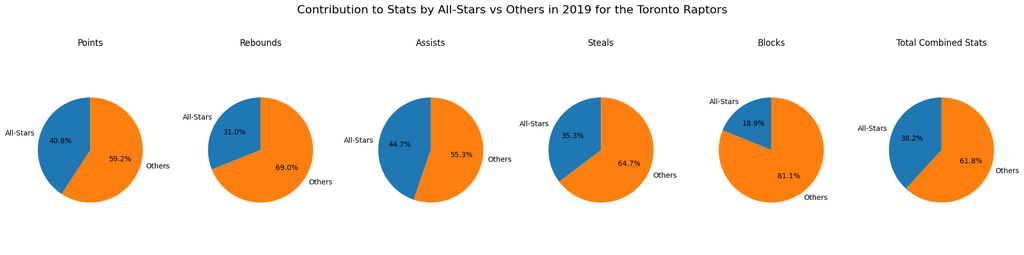

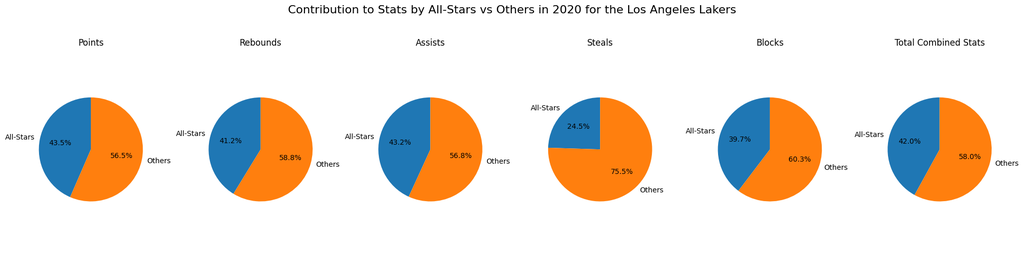

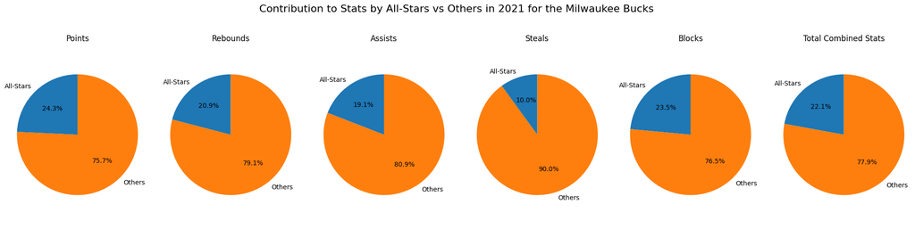

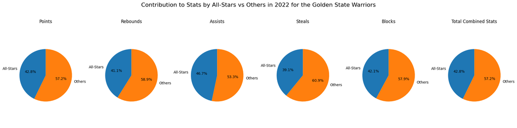

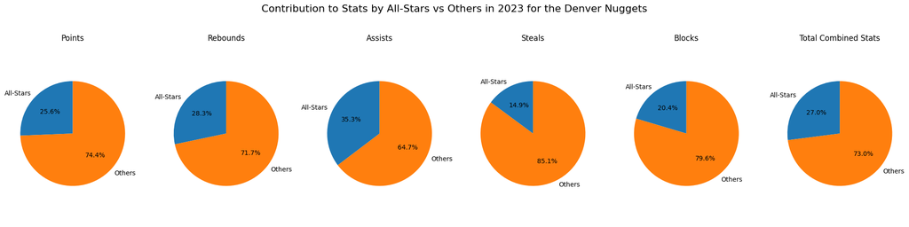

```python
total_stats_df = total_stats_df[['Year', 'Team', 'Category', 'PTS', 'TRB', 'AST', 'TOV', 'STL', 'BLK']]
metrics = ['PTS', 'TRB', 'AST', 'STL', 'BLK']
metric_dict = {'PTS':'Points', 'TRB': 'Rebounds', 'AST': 'Assists', 'STL': 'Steals', 'BLK':'Blocks'}

for year in years:
    year_stats = total_stats_df[total_stats_df['Year'] == year]

    fig, axes = plt.subplots(1, len(metrics) + 1, figsize=(20, 5))
    fig.suptitle(f'Contribution to Stats by All-Stars vs Others in {year} for the {winners[year]}', fontsize=16)

    for i, metric in enumerate(metrics):
        allstar_metric = year_stats[year_stats['Category'] == 'All-Stars'][metric].fillna(0).values[0]
        other_metric = year_stats[year_stats['Category'] == 'Others'][metric].fillna(0).values[0]

        labels = ['All-Stars', 'Others']
        sizes = [allstar_metric, other_metric]

        ax = axes[i]
        ax.pie(sizes, labels=labels, autopct='%1.1f%%', startangle=90)
        ax.axis('equal')
        ax.set_title(metric_dict[metric])

    total_allstar_stats = year_stats[year_stats['Category'] == 'All-Stars'][metrics].sum().sum()
    total_other_stats = year_stats[year_stats['Category'] == 'Others'][metrics].sum().sum()

    labels = ['All-Stars', 'Others']
    sizes = [total_allstar_stats, total_other_stats]

    ax = axes[len(metrics)]
    ax.pie(sizes, labels=labels, autopct='%1.1f%%', startangle=90)
    ax.axis('equal')
    ax.set_title('Total Combined Stats')

    plt.tight_layout(rect=[0, 0, 1, 0.95])
    plt.show()
```

Overall, we see that all championship teams have a considerable amount of contribution made by their all stars. This makes sense as they are technically the best players on each team and should contribute the most to the overall success.

We now extend this analysis to the other teams. Instead of simply displaying the same charts for each team, we decided it was better to plot all the team's points on a graph for each year to understand how skewed the contributions to success were across all playoff team. The x-axis is for the contributions made by all stars while the y-axis is for the contributions made by the rest of the team. There are once again 6 plots, detailing the statistice for points, rebounds, assists, steals, blocks, and the sum of all previously mentioined stats. We see an overall downward trend, where the more an allstar produces, the less the other players will produce. While we can hypothesize this, we are not yet able to confirm this information. In the next step, we will use more standard ways to determine the trend.

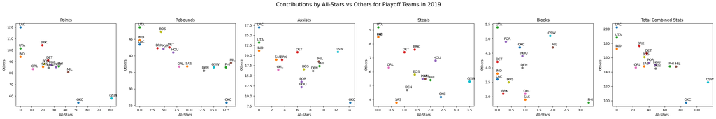

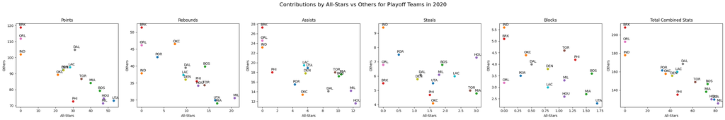

[figure not shown]

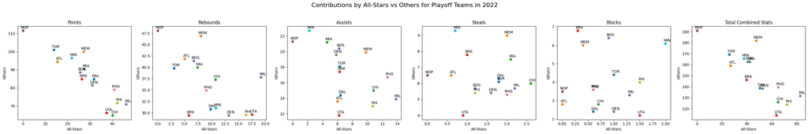

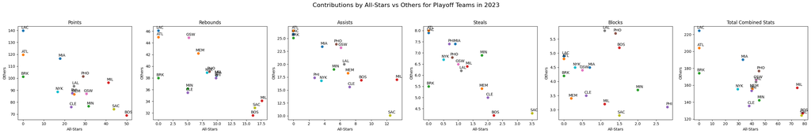

```python
non_champion_stats_df = pd.DataFrame(columns=['Year', 'Team', 'Category', 'PTS', 'TRB', 'AST', 'TOV', 'STL', 'BLK'])

for year in years:
    winning_team = winners[year]
    all_teams_stats = dataframes[year]

    all_teams_stats[['G', 'MP', 'PTS', 'TRB', 'AST', 'TOV', 'STL', 'BLK']] = all_teams_stats[['G', 'MP', 'PTS', 'TRB', 'AST', 'TOV', 'STL', 'BLK']].apply(pd.to_numeric, errors='coerce')

    non_champion_teams_stats = all_teams_stats[all_teams_stats['Tm'] != winning_team]

    for team in non_champion_teams_stats['Tm'].unique():
        team_stats = non_champion_teams_stats[non_champion_teams_stats['Tm'] == team]

        allstar_stats = team_stats[team_stats['Player'].isin(allstars[year])]
        other_stats = team_stats[~team_stats['Player'].isin(allstars[year])]

        allstar_total_stats = allstar_stats[['G', 'MP', 'PTS', 'TRB', 'AST', 'TOV', 'STL', 'BLK']].sum()
        other_total_stats = other_stats[['G', 'MP', 'PTS', 'TRB', 'AST', 'TOV', 'STL', 'BLK']].sum()

        allstar_total_stats['Year'] = year
        allstar_total_stats['Team'] = team
        allstar_total_stats['Category'] = 'All-Stars'

        other_total_stats['Year'] = year
        other_total_stats['Team'] = team
        other_total_stats['Category'] = 'Others'

        allstar_total_stats = allstar_total_stats.to_frame().T
        other_total_stats = other_total_stats.to_frame().T

        non_champion_stats_df = pd.concat([non_champion_stats_df, allstar_total_stats], ignore_index=True)
        non_champion_stats_df = pd.concat([non_champion_stats_df, other_total_stats], ignore_index=True)

non_champion_stats_df = non_champion_stats_df[['Year', 'Team', 'Category', 'PTS', 'TRB', 'AST', 'TOV', 'STL', 'BLK']]
metrics = ['PTS', 'TRB', 'AST', 'STL', 'BLK']
metric_dict = {'PTS': 'Points', 'TRB': 'Rebounds', 'AST': 'Assists', 'STL': 'Steals', 'BLK': 'Blocks'}

for year in years:
    fig, axes = plt.subplots(1, len(metrics) + 1, figsize=(30, 5))
    fig.suptitle(f'Contributions by All-Stars vs Others for Playoff Teams in {year}', fontsize=16)

    for i, metric in enumerate(metrics):
        ax = axes[i]
        for team in non_champion_stats_df[non_champion_stats_df['Year'] == year]['Team'].unique():
            team_stats = non_champion_stats_df[(non_champion_stats_df['Year'] == year) & (non_champion_stats_df['Team'] == team)]

            allstar_metric = team_stats[team_stats['Category'] == 'All-Stars'][metric].fillna(0).values
            other_metric = team_stats[team_stats['Category'] == 'Others'][metric].fillna(0).values

            if len(allstar_metric) == 0 or len(other_metric) == 0:
                continue

            ax.scatter(allstar_metric, other_metric)
            for x, y in zip(allstar_metric, other_metric):
                team_abbr = list(teams.keys())[list(teams.values()).index(team)]
                ax.annotate(team_abbr, (x, y), textcoords="offset points", xytext=(5,5), ha='center')

        ax.set_xlabel('All-Stars')
        ax.set_ylabel('Others')
        ax.set_title(metric_dict[metric])

    ax = axes[len(metrics)]
    for team in non_champion_stats_df[non_champion_stats_df['Year'] == year]['Team'].unique():
        team_stats = non_champion_stats_df[(non_champion_stats_df['Year'] == year) & (non_champion_stats_df['Team'] == team)]

        total_allstar_stats = team_stats[team_stats['Category'] == 'All-Stars'][metrics].fillna(0).sum(axis=1).values
        total_other_stats = team_stats[team_stats['Category'] == 'Others'][metrics].fillna(0).sum(axis=1).values

        if len(total_allstar_stats) == 0 or len(total_other_stats) == 0:
            continue

        ax.scatter(total_allstar_stats, total_other_stats)
        for x, y in zip(total_allstar_stats, total_other_stats):
            team_abbr = list(teams.keys())[list(teams.values()).index(team)]
            ax.annotate(team_abbr, (x, y), textcoords="offset points", xytext=(5,5), ha='center')

    ax.set_xlabel('All-Stars')
    ax.set_ylabel('Others')
    ax.set_title('Total Combined Stats')

    plt.tight_layout(rect=[0, 0, 1, 0.95])
    plt.show()
```

# Hypothesis Testing and Machine Learning

## Line of best fit

In this section of the code, we have transferred the graphs from the previous step but also included the result of the NBA champion for that year. In order to provide absolute clarity, the NBA champion is a diamond figure while the other points are circles.

```
Line of best fit for total stats: y = -0.67x + 182.42
```

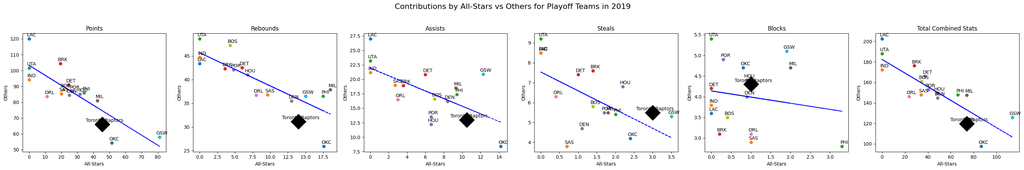

```
Line of best fit for total stats: y = -0.72x + 189.95
```

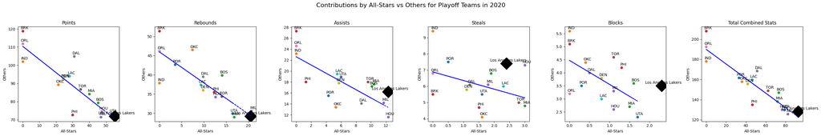

```
Line of best fit for total stats: y = -0.79x + 195.48
```

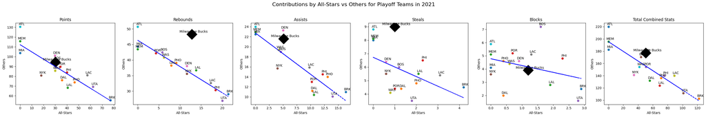

```
Line of best fit for total stats: y = -0.82x + 189.63
```

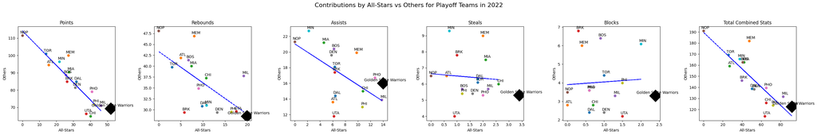

```
Line of best fit for total stats: y = -0.84x + 196.38
```

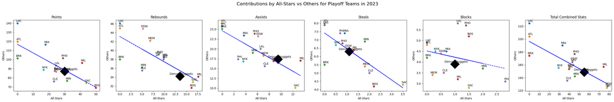

```python
all_teams_stats_df = pd.DataFrame(columns=['Year', 'Team', 'Category', 'PTS', 'TRB', 'AST', 'TOV', 'STL', 'BLK'])

for year in years:
    winning_team = winners[year]
    all_teams_stats = dataframes[year]

    all_teams_stats[['G', 'MP', 'PTS', 'TRB', 'AST', 'TOV', 'STL', 'BLK']] = all_teams_stats[['G', 'MP', 'PTS', 'TRB', 'AST', 'TOV', 'STL', 'BLK']].apply(pd.to_numeric, errors='coerce')

    for team in all_teams_stats['Tm'].unique():
        team_stats = all_teams_stats[all_teams_stats['Tm'] == team]

        allstar_stats = team_stats[team_stats['Player'].isin(allstars[year])]
        other_stats = team_stats[~team_stats['Player'].isin(allstars[year])]

        allstar_total_stats = allstar_stats[['G', 'MP', 'PTS', 'TRB', 'AST', 'TOV', 'STL', 'BLK']].sum()
        other_total_stats = other_stats[['G', 'MP', 'PTS', 'TRB', 'AST', 'TOV', 'STL', 'BLK']].sum()

        allstar_total_stats['Year'] = year
        allstar_total_stats['Team'] = team
        allstar_total_stats['Category'] = 'All-Stars'

        other_total_stats['Year'] = year
        other_total_stats['Team'] = team
        other_total_stats['Category'] = 'Others'

        allstar_total_stats = allstar_total_stats.to_frame().T
        other_total_stats = other_total_stats.to_frame().T

        all_teams_stats_df = pd.concat([all_teams_stats_df, allstar_total_stats], ignore_index=True)
        all_teams_stats_df = pd.concat([all_teams_stats_df, other_total_stats], ignore_index=True)

all_teams_stats_df = all_teams_stats_df[['Year', 'Team', 'Category', 'PTS', 'TRB', 'AST', 'TOV', 'STL', 'BLK']]
metrics = ['PTS', 'TRB', 'AST', 'STL', 'BLK']
metric_dict = {'PTS': 'Points', 'TRB': 'Rebounds', 'AST': 'Assists', 'STL': 'Steals', 'BLK': 'Blocks'}

def add_best_fit_line(ax, x, y, print_val):
    m, b = np.polyfit(x, y, 1)
    ax.plot(x, m*x + b, color='blue', linestyle='--')
    if(print_val):
        print(f"Line of best fit for total stats: y = {m:.2f}x + {b:.2f}")

for year in years:
    fig, axes = plt.subplots(1, len(metrics) + 1, figsize=(30, 5))
    fig.suptitle(f'Contributions by All-Stars vs Others for Playoff Teams in {year}', fontsize=16)

    winning_team = winners[year]
    winning_team_stats = all_teams_stats_df[(all_teams_stats_df['Year'] == year) & (all_teams_stats_df['Team'] == winning_team)]

    for i, metric in enumerate(metrics):
        ax = axes[i]
        x_data = []
        y_data = []

        for team in all_teams_stats_df[all_teams_stats_df['Year'] == year]['Team'].unique():
            if team == winning_team:
                continue

            team_stats = all_teams_stats_df[(all_teams_stats_df['Year'] == year) & (all_teams_stats_df['Team'] == team)]

            allstar_metric = team_stats[team_stats['Category'] == 'All-Stars'][metric].fillna(0).values
            other_metric = team_stats[team_stats['Category'] == 'Others'][metric].fillna(0).values

            if len(allstar_metric) == 0 or len(other_metric) == 0:
                continue

            x_data.extend(allstar_metric)
            y_data.extend(other_metric)

            ax.scatter(allstar_metric, other_metric, label=team)
            for x, y in zip(allstar_metric, other_metric):
                team_abbr = list(teams.keys())[list(teams.values()).index(team)]
                ax.annotate(team_abbr, (x, y), textcoords="offset points", xytext=(5,5), ha='center')

        if x_data and y_data:
            add_best_fit_line(ax, np.array(x_data), np.array(y_data), False)

        allstar_metric = winning_team_stats[winning_team_stats['Category'] == 'All-Stars'][metric].fillna(0).values
        other_metric = winning_team_stats[winning_team_stats['Category'] == 'Others'][metric].fillna(0).values

        if len(allstar_metric) != 0 and len(other_metric) != 0:
            ax.scatter(allstar_metric, other_metric, color='black', marker='D', s=500, label='Champion')
            for x, y in zip(allstar_metric, other_metric):
                ax.annotate(winning_team, (x, y), textcoords="offset points", xytext=(5,5), ha='center', color='black')

        ax.set_xlabel('All-Stars')
        ax.set_ylabel('Others')
        ax.set_title(metric_dict[metric])

    ax = axes[len(metrics)]
    x_data = []
    y_data = []

    for team in all_teams_stats_df[all_teams_stats_df['Year'] == year]['Team'].unique():
        team_stats = all_teams_stats_df[(all_teams_stats_df['Year'] == year) & (all_teams_stats_df['Team'] == team)]

        total_allstar_stats = team_stats[team_stats['Category'] == 'All-Stars'][metrics].fillna(0).sum(axis=1).values
        total_other_stats = team_stats[team_stats['Category'] == 'Others'][metrics].fillna(0).sum(axis=1).values

        if len(total_allstar_stats) == 0 or len(total_other_stats) == 0:
            continue

        x_data.extend(total_allstar_stats)
        y_data.extend(total_other_stats)

        ax.scatter(total_allstar_stats, total_other_stats)
        for x, y in zip(total_allstar_stats, total_other_stats):
            team_abbr = list(teams.keys())[list(teams.values()).index(team)]
            ax.annotate(team_abbr, (x, y), textcoords="offset points", xytext=(5,5), ha='center')

    if x_data and y_data:
        add_best_fit_line(ax, np.array(x_data), np.array(y_data), True)

    total_allstar_stats = winning_team_stats[winning_team_stats['Category'] == 'All-Stars'][metrics].fillna(0).sum(axis=1).values
    total_other_stats = winning_team_stats[winning_team_stats['Category'] == 'Others'][metrics].fillna(0).sum(axis=1).values

    if len(total_allstar_stats) != 0 and len(total_other_stats) != 0:
        ax.scatter(total_allstar_stats, total_other_stats, color='black', marker='D', s=500, label='Champion')
        for x, y in zip(total_allstar_stats, total_other_stats):
            ax.annotate(winning_team, (x, y), textcoords="offset points", xytext=(5,5), ha='center', color='black')

    ax.set_xlabel('All-Stars')
    ax.set_ylabel('Others')
    ax.set_title('Total Combined Stats')

    plt.tight_layout(rect=[0, 0, 1, 0.95])
    plt.show()
```

## Machine Learning Model

Now we will use AI to predict NBA winners. We first need to prepare a dataset for the model to use for training. First, we create an empty DataFrame all_seasons_stats_df with columns for year, team, category, various statistics (points, rebounds, assists, turnovers, steals, blocks), and whether the team was the champion. The statistics columns are converted to numeric values. Then, for each team, the statistics are divided into those of all-star players and other players. These statistics are summed, and a new row is created that includes the combined statistics, the year, team, and a label indicating if the team won the championship. Finally, the features (statistics) and labels (championship status) are extracted into arrays X and y for use in model training.

```python
all_seasons_stats_df = pd.DataFrame(columns=['Year', 'Team', 'Category', 'PTS', 'TRB', 'AST', 'TOV', 'STL', 'BLK', 'Champion'])

for year in years:
    winning_team = winners[year]
    all_teams_stats = dataframes[year]

    all_teams_stats[['G', 'MP', 'PTS', 'TRB', 'AST', 'TOV', 'STL', 'BLK']] = all_teams_stats[['G', 'MP', 'PTS', 'TRB', 'AST', 'TOV', 'STL', 'BLK']].apply(pd.to_numeric, errors='coerce')

    for team in all_teams_stats['Tm'].unique():
        team_stats = all_teams_stats[all_teams_stats['Tm'] == team]

        allstar_stats = team_stats[team_stats['Player'].isin(allstars[year])]
        other_stats = team_stats[~team_stats['Player'].isin(allstars[year])]

        allstar_total_stats = allstar_stats[['G', 'MP', 'PTS', 'TRB', 'AST', 'TOV', 'STL', 'BLK']].sum()
        other_total_stats = other_stats[['G', 'MP', 'PTS', 'TRB', 'AST', 'TOV', 'STL', 'BLK']].sum()

        total_stats = allstar_total_stats + other_total_stats
        total_stats['Year'] = year
        total_stats['Team'] = team
        total_stats['Champion'] = 1 if team == winning_team else 0

        total_stats = total_stats.to_frame().T

        all_seasons_stats_df = pd.concat([all_seasons_stats_df, total_stats], ignore_index=True)

all_seasons_stats_df = all_seasons_stats_df.fillna(0)

all_seasons_stats_df['Champion'] = all_seasons_stats_df['Champion'].astype(int)

features = ['PTS', 'TRB', 'AST', 'TOV', 'STL', 'BLK']
X = all_seasons_stats_df[features].values
y = all_seasons_stats_df['Champion'].values
```

We will now train a neural network model to predict NBA champions based on team statistics. The data is first split into training and testing sets using an 80-20 split with the train_test_split function. A neural network model is defined using Keras' Sequential API which is linked here:

https://www.tensorflow.org/guide/keras/sequential_model

The model consists of two hidden layers, each with 64 neurons and ReLU activation functions, and an output layer with a single neuron and a sigmoid activation function, suitable for binary classification. The model is compiled with the Adam optimizer, binary cross-entropy loss function, and accuracy as the evaluation metric. The resulting model is ready to be trained on the training data.

```python
X_train, X_test, y_train, y_test = train_test_split(X, y, test_size=0.2, random_state=42)

scaler = StandardScaler()
X_train = scaler.fit_transform(X_train)
X_test = scaler.transform(X_test)

model = Sequential([
    Dense(64, activation='relu', input_shape=(X_train.shape[1],)),
    Dense(64, activation='relu'),
    Dense(1, activation='sigmoid')
])

model.compile(optimizer='adam', loss='binary_crossentropy', metrics=['accuracy'])
```

This code snippet is used to train the neural network model while printing the accuracy at the end of each epoch. The model is then trained using the fit method with the training data (X_train, y_train) for 10 epochs and a batch size of 16. The validation data (X_test, y_test) is provided to monitor the model's performance on unseen data during training. The PrintAccuracy callback is passed to the fit method to enable the printing of accuracy metrics after each epoch, allowing for us to monitor the model's training progress for each epoch.

```python
class PrintAccuracy(tf.keras.callbacks.Callback):
    def on_epoch_end(self, epoch, logs=None):
        print(f"Epoch {epoch + 1}, Accuracy: {logs['accuracy']:.4f}, Val Accuracy: {logs['val_accuracy']:.4f}")

history = model.fit(X_train, y_train, epochs=10, batch_size=16, validation_data=(X_test, y_test), callbacks=[PrintAccuracy()])
```

```
1/5 ━━━━━━━━━━━━━━━━━━━━ 0s 12ms/step - accuracy: 0.9375 - loss: 0.0995Epoch 1, Accuracy: 0.9559, Val Accuracy: 1.0000
5/5 ━━━━━━━━━━━━━━━━━━━━ 0s 9ms/step - accuracy: 0.9497 - loss: 0.0839 - val_accuracy: 1.0000 - val_loss: 0.0282
1/5 ━━━━━━━━━━━━━━━━━━━━ 0s 12ms/step - accuracy: 0.8750 - loss: 0.1556Epoch 2, Accuracy: 0.9559, Val Accuracy: 1.0000
5/5 ━━━━━━━━━━━━━━━━━━━━ 0s 5ms/step - accuracy: 0.9393 - loss: 0.0916 - val_accuracy: 1.0000 - val_loss: 0.0288
1/5 ━━━━━━━━━━━━━━━━━━━━ 0s 11ms/step - accuracy: 0.9375 - loss: 0.1001Epoch 3, Accuracy: 0.9559, Val Accuracy: 1.0000
5/5 ━━━━━━━━━━━━━━━━━━━━ 0s 4ms/step - accuracy: 0.9497 - loss: 0.0808 - val_accuracy: 1.0000 - val_loss: 0.0290
1/5 ━━━━━━━━━━━━━━━━━━━━ 0s 12ms/step - accuracy: 0.8750 - loss: 0.1197Epoch 4, Accuracy: 0.9559, Val Accuracy: 1.0000
5/5 ━━━━━━━━━━━━━━━━━━━━ 0s 4ms/step - accuracy: 0.9358 - loss: 0.0831 - val_accuracy: 1.0000 - val_loss: 0.0291
1/5 ━━━━━━━━━━━━━━━━━━━━ 0s 11ms/step - accuracy: 1.0000 - loss: 0.0479Epoch 5, Accuracy: 0.9559, Val Accuracy: 1.0000
5/5 ━━━━━━━━━━━━━━━━━━━━ 0s 4ms/step - accuracy: 0.9653 - loss: 0.0690 - val_accuracy: 1.0000 - val_loss: 0.0285
1/5 ━━━━━━━━━━━━━━━━━━━━ 0s 11ms/step - accuracy: 0.8750 - loss: 0.1462Epoch 6, Accuracy: 0.9559, Val Accuracy: 1.0000
5/5 ━━━━━━━━━━━━━━━━━━━━ 0s 4ms/step - accuracy: 0.9306 - loss: 0.0926 - val_accuracy: 1.0000 - val_loss: 0.0278
1/5 ━━━━━━━━━━━━━━━━━━━━ 0s 12ms/step - accuracy: 1.0000 - loss: 0.0463Epoch 7, Accuracy: 0.9559, Val Accuracy: 1.0000
5/5 ━━━━━━━━━━━━━━━━━━━━ 0s 4ms/step - accuracy: 0.9731 - loss: 0.0575 - val_accuracy: 1.0000 - val_loss: 0.0275
1/5 ━━━━━━━━━━━━━━━━━━━━ 0s 11ms/step - accuracy: 1.0000 - loss: 0.0186Epoch 8, Accuracy: 0.9559, Val Accuracy: 1.0000
5/5 ━━━━━━━━━━━━━━━━━━━━ 0s 4ms/step - accuracy: 0.9740 - loss: 0.0479 - val_accuracy: 1.0000 - val_loss: 0.0287
1/5 ━━━━━━━━━━━━━━━━━━━━ 0s 12ms/step - accuracy: 0.9375 - loss: 0.0733Epoch 9, Accuracy: 0.9559, Val Accuracy: 1.0000
5/5 ━━━━━━━━━━━━━━━━━━━━ 0s 4ms/step - accuracy: 0.9549 - loss: 0.0710 - val_accuracy: 1.0000 - val_loss: 0.0312
1/5 ━━━━━━━━━━━━━━━━━━━━ 0s 11ms/step - accuracy: 0.9375 - loss: 0.0743Epoch 10, Accuracy: 0.9559, Val Accuracy: 1.0000
5/5 ━━━━━━━━━━━━━━━━━━━━ 0s 4ms/step - accuracy: 0.9549 - loss: 0.0666 - val_accuracy: 1.0000 - val_loss: 0.0324
```

Upon completing the training of the model, we will measure its accuracy on data it has not yet processed. In the next section, I once again collected data regarding playoff statistics for all players and all star selections. This rendition, however, I selected data for five different years: instead of 2019 to 2023, I scraped the web for the years 2014 to 2018. Selected this data to test the model will help us understand if the model has truly learned of simply memorized information.

```python
dataframes_test = {}

years = ["2014", "2015", "2016", "2017", "2018"]

for year in years:
    url = f"https://www.basketball-reference.com/playoffs/NBA_{year}_per_game.html"
    driver = webdriver.Chrome()
    driver.get(url)
    driver.implicitly_wait(10)
    html = driver.page_source
    soup = BeautifulSoup(html, 'html.parser')
    table = soup.find('table', {"class": "sortable stats_table now_sortable"})
    df_list = pd.read_html(str(table))
    dataframes_test[year] = df_list[0]

allstars_test = {}
for year in years:
    url = f"https://basketball.realgm.com/nba/allstar/game/rosters/{year}"
    driver = webdriver.Chrome()
    driver.get(url)
    driver.implicitly_wait(10)
    html = driver.page_source
    soup = BeautifulSoup(html, 'html.parser')
    tables = soup.find_all('table', {"class": "basketball compact"})
    players = []

    for table in tables:
        df_list = pd.read_html(str(table))
        players.extend(df_list[0]['Player'])

    allstars_test[year] = players
```

Here, we do a final mapping of the team values so that instead of abbreviations, we get the actual team name.

```python
years_test = ["2014", "2015", "2016", "2017", "2018"]

for year in years_test:
    dataframes_test[year]['Tm'] = dataframes_test[year]['Tm'].map(teams)

print(dataframes_test)
```

[output not shown]

[output cut: 116 more lines]

In order to understand the accuracy of the model, I used three functions, accuracy_score, confusion_matrix, and classification_report, from sklearn.metrics. You can learn more about the structure here:

https://scikit-learn.org/stable/modules/model_evaluation.html

We first prepare and evaluate a neural network model on a test dataset to predict NBA champions based on team statistics. For each year, we identify the winning team and retrieves the statistics for all teams, converting relevant columns to numeric values. We then calculate the total statistics for all-star players and other players separately and combine them into a single row with a label indicating whether the team won the championship. The features are standardized using the previously fitted scaler, and predictions are made using the trained model. The accuracy, confusion matrix, and classification report are printed to evaluate the model's performance on the test data.

```python
all_seasons_stats_df_test = pd.DataFrame(columns=['Year', 'Team', 'Category', 'PTS', 'TRB', 'AST', 'TOV', 'STL', 'BLK', 'Champion'])


winners_test = {
    "2014": "San Antonio Spurs",
    "2015": "Golden State Warriors",
    "2016": "Cleveland Cavaliers",
    "2017": "Golden State Warriors",
    "2018": "Golden State Warriors"
}

years_test = ["2014", "2015", "2016", "2017", "2018"]


for year in years_test:
    winning_team = winners_test[year]
    all_teams_stats = dataframes_test[year]

    all_teams_stats[['G', 'MP', 'PTS', 'TRB', 'AST', 'TOV', 'STL', 'BLK']] = all_teams_stats[['G', 'MP', 'PTS', 'TRB', 'AST', 'TOV', 'STL', 'BLK']].apply(pd.to_numeric, errors='coerce')

    for team in all_teams_stats['Tm'].unique():
        team_stats = all_teams_stats[all_teams_stats['Tm'] == team]

        allstar_stats = team_stats[team_stats['Player'].isin(allstars_test[year])]
        other_stats = team_stats[~team_stats['Player'].isin(allstars_test[year])]

        allstar_total_stats = allstar_stats[['G', 'MP', 'PTS', 'TRB', 'AST', 'TOV', 'STL', 'BLK']].sum()
        other_total_stats = other_stats[['G', 'MP', 'PTS', 'TRB', 'AST', 'TOV', 'STL', 'BLK']].sum()

        total_stats = allstar_total_stats + other_total_stats
        total_stats['Year'] = year
        total_stats['Team'] = team
        total_stats['Champion'] = 1 if team == winning_team else 0

        total_stats = total_stats.to_frame().T

        all_seasons_stats_df_test = pd.concat([all_seasons_stats_df_test, total_stats], ignore_index=True)

all_seasons_stats_df_test = all_seasons_stats_df_test.fillna(0)
all_seasons_stats_df_test['Champion'] = all_seasons_stats_df_test['Champion'].astype(int)

features = ['PTS', 'TRB', 'AST', 'TOV', 'STL', 'BLK']
X_test = all_seasons_stats_df_test[features].values
y_test = all_seasons_stats_df_test['Champion'].values

X_test = scaler.transform(X_test)

y_pred_test = model.predict(X_test)
y_pred_test = (y_pred_test > 0.5).astype(int)

print("Accuracy:", accuracy_score(y_test, y_pred_test))
print("Confusion Matrix:\n", confusion_matrix(y_test, y_pred_test))
print("Classification Report:\n", classification_report(y_test, y_pred_test))
```

```
3/3 ━━━━━━━━━━━━━━━━━━━━ 0s 689us/step
Accuracy: 0.9404761904761905
Confusion Matrix:
 [[79  0]
 [ 5  0]]
Classification Report:
               precision    recall  f1-score   support

           0       0.94      1.00      0.97        79
           1       0.00      0.00      0.00         5

    accuracy                           0.94        84
   macro avg       0.47      0.50      0.48        84
weighted avg       0.88      0.94      0.91        84
```

# Insight and Policy Decision